# pml_assignment

zj

July 19, 2017

# 08 Practical machine learning, week4 assignment

# The goal of your project is to predict the manner in which they did the exercise. This is the “classe” variable in the training set. You may use any of the other variables to predict with. You should create a report describing how you built your model, how you used cross validation, what you think the expected out of sample error is, and why you made the choices you did. You will also use your prediction model to predict 20 different test cases.

# Your submission should consist of a link to a Github repo with your R markdown and compiled HTML file describing your analysis. Please constrain the text of the writeup to < 2000 words and the number of figures to be less than 5. It will make it easier for the graders if you submit a repo with a gh-pages branch so the HTML page can be viewed online (and you always want to make it easy on graders :-). You should also apply your machine learning algorithm to the 20 test cases available in the test data above. Please submit your predictions in appropriate format to the programming assignment for automated grading. See the programming assignment for additional details.

```r
getwd()
```

```
## [1] "/home/upsman/Downloads/courseraDataScience_byme/PracticalMachineLearning/assignment"
```

```r
setwd("./data")
getwd()
```

```
## [1] "/home/upsman/Downloads/courseraDataScience_byme/PracticalMachineLearning/assignment/data"
```

```r
download.file("https://d396qusza40orc.cloudfront.net/predmachlearn/pml-training.csv",
              destfile = "./training.csv",
              method = "curl")

download.file("https://d396qusza40orc.cloudfront.net/predmachlearn/pml-testing.csv",
              destfile = "./testing.csv",
              method = "curl")
list.files()
```

```
## [1] "testing.csv"  "training.csv"
```

```r
library(tidyverse)
library(caret)
```

```r
#install.packages("corrplot")
library(corrplot)
# download the datasets
trainData = read_csv("training.csv")
testData = read_csv("testing.csv")
# create a partition with the training dataset
set.seed(100)
inTrain <- createDataPartition(trainData$classe, p = 0.7, list = FALSE)
TrainSet <- trainData[inTrain, ]
ValidationSet  <- trainData[-inTrain, ]
dim(TrainSet)
```

```
## [1] 13737   160
```

```r
dim(ValidationSet)
```

```
## [1] 5885  160
```

# remove Near Zero variance (NZV) variables and the ID variables as well.

```r
# remove variables with Nearly Zero Variance
NZV <- nearZeroVar(TrainSet)
TrainSet <- TrainSet[, -NZV]
ValidationSet  <- ValidationSet[, -NZV]
dim(TrainSet)
```

```
## [1] 13737   127
```

```r
dim(ValidationSet)
```

```
## [1] 5885  127
```

# Get rid of variables with mostly NA

```r
# remove variables that are mostly NA
AllNA    <- sapply(TrainSet, function(x) mean(is.na(x))) > 0.95
TrainSet <- TrainSet[, AllNA==FALSE]
ValidationSet  <- ValidationSet[, AllNA==FALSE]
dim(TrainSet)
```

```
## [1] 13737    59
```

```r
dim(ValidationSet)
```

```
## [1] 5885   59
```

# remove columns 1-5

```r
# remove identification only variables (columns 1 to 5)
TrainSet <- TrainSet[, -(1:5)]
ValidationSet  <- ValidationSet[, -(1:5)]
dim(TrainSet)
```

```
## [1] 13737    54
```

```r
dim(ValidationSet)
```

```
## [1] 5885   54
```

# A correlation among variables is analysed before proceeding to the modeling procedures.

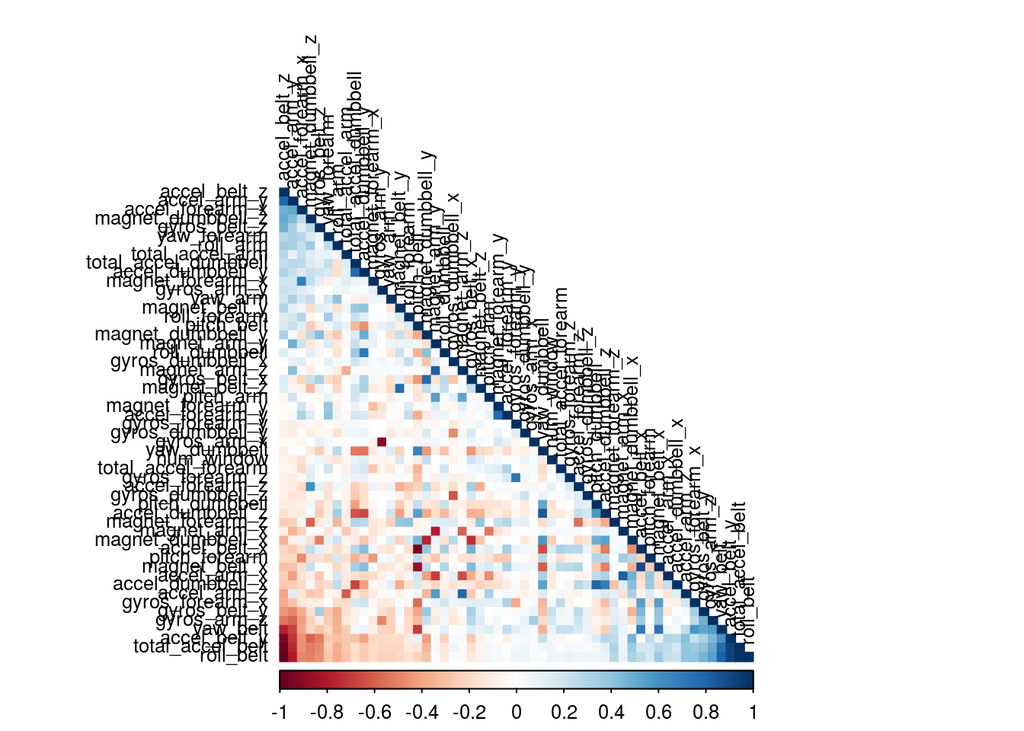

```r
corMatrix <- cor(TrainSet[, -54],use = "complete.obs")
corrplot(corMatrix, order = "FPC", method = "color", type = "lower",
         tl.cex = 0.8, tl.col = rgb(0, 0, 0))
```

# fit based on Random Forest model

```r
set.seed(101)
controlRF <- trainControl(method="cv", number=3, verboseIter=FALSE)
modFitRandForest <- train(classe ~ ., data=TrainSet, method="rf", na.action = na.omit,
                          trControl=controlRF)
modFitRandForest$finalModel
```

```
##
## Call:
##  randomForest(x = x, y = y, mtry = param$mtry)
##                Type of random forest: classification
##                      Number of trees: 500
## No. of variables tried at each split: 27
##
##         OOB estimate of  error rate: 0.25%
## Confusion matrix:
##      A    B    C    D    E  class.error
## A 3904    1    0    0    0 0.0002560819
## B    6 2647    3    2    0 0.0041384500
## C    0    7 2389    0    0 0.0029215359
## D    0    0    7 2243    2 0.0039964476
## E    0    0    0    6 2519 0.0023762376
```

```r
# prediction on Test dataset
predictRandForest <- predict(modFitRandForest, newdata=ValidationSet)
confMatRandForest <- confusionMatrix(predictRandForest, ValidationSet$classe)
confMatRandForest
```

```
## Confusion Matrix and Statistics
##
##           Reference
## Prediction    A    B    C    D    E
##          A 1674    5    0    0    0
##          B    0 1134    1    0    0
##          C    0    0 1025    7    0
##          D    0    0    0  957    0
##          E    0    0    0    0 1082
##
## Overall Statistics
##
##                Accuracy : 0.9978
##                  95% CI : (0.9962, 0.9988)
##     No Information Rate : 0.2845
##     P-Value [Acc > NIR] : < 2.2e-16
##
##                   Kappa : 0.9972
##  Mcnemar's Test P-Value : NA
##
## Statistics by Class:
##
##                      Class: A Class: B Class: C Class: D Class: E
## Sensitivity            1.0000   0.9956   0.9990   0.9927   1.0000
## Specificity            0.9988   0.9998   0.9986   1.0000   1.0000
## Pos Pred Value         0.9970   0.9991   0.9932   1.0000   1.0000
## Neg Pred Value         1.0000   0.9989   0.9998   0.9986   1.0000
## Prevalence             0.2845   0.1935   0.1743   0.1638   0.1839
## Detection Rate         0.2845   0.1927   0.1742   0.1626   0.1839
## Detection Prevalence   0.2853   0.1929   0.1754   0.1626   0.1839
## Balanced Accuracy      0.9994   0.9977   0.9988   0.9964   1.0000
```

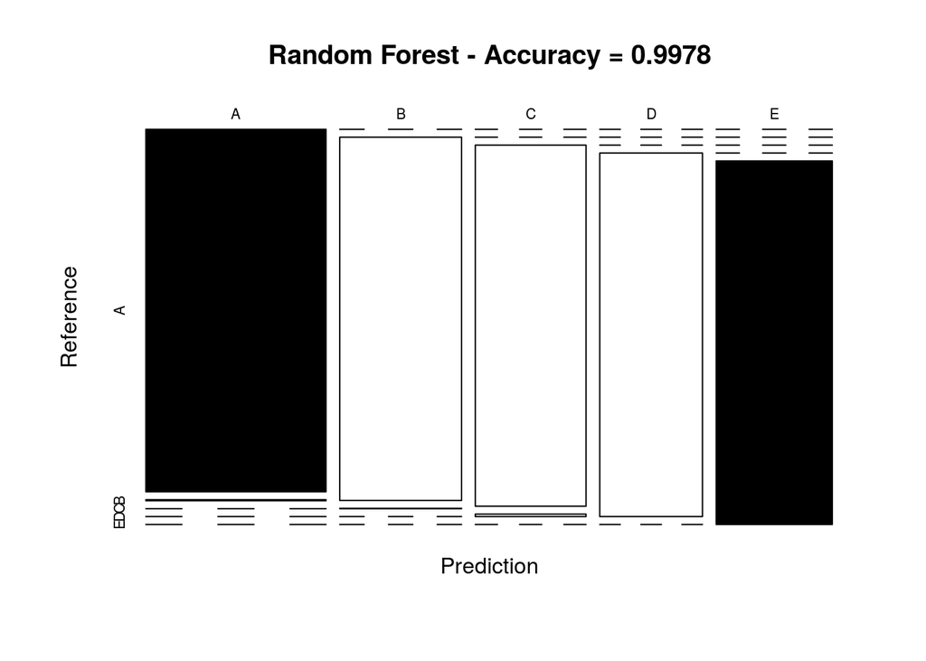

```r
# plot matrix results
plot(confMatRandForest$table, col = confMatRandForest$byClass,
     main = paste("Random Forest - Accuracy =",
                  round(confMatRandForest$overall['Accuracy'], 4)))
```

#Decision Trees

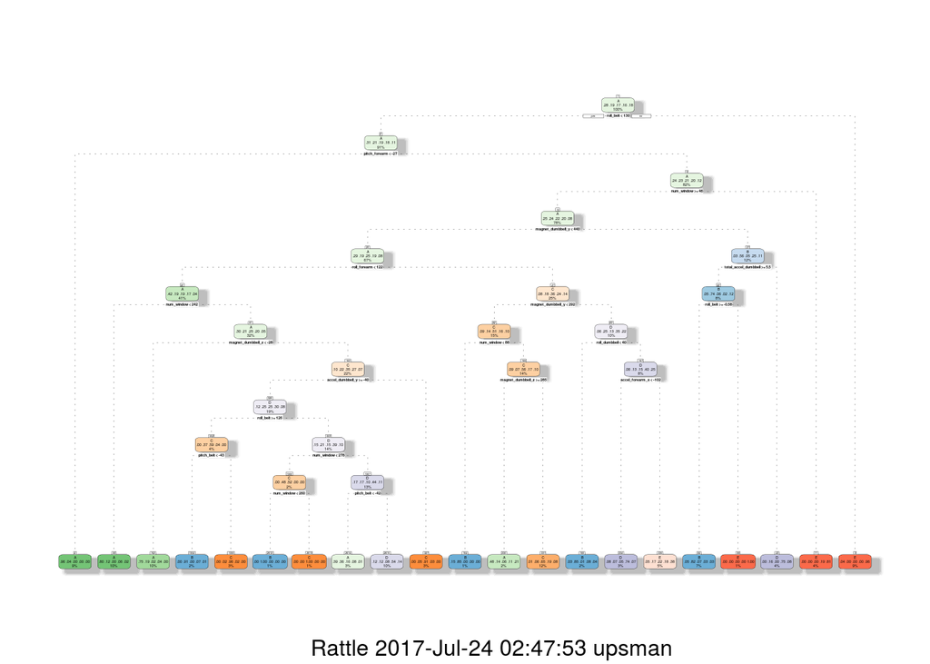

```r
library(rpart)
library(rpart.plot)
library(rattle)
library(randomForest)
set.seed(102)
modFitDecTree <- rpart(classe ~ ., data=TrainSet, method="class")
fancyRpartPlot(modFitDecTree)
```